# Google Data Analyst Capstone

Avi Ghosh

## Main business question: How to convert rec bike users into members?

The goal initially is to point out how differently casual and members use the bike services. Using this information, advertisement and marketing campaigns can be put in place that would strategize to convert the appropriate segment of people.

## Include the correct packages & libraries.

First we load the required libraries

```r
library(dplyr)
library(tidyverse)
library(lubridate)
```

```r
library(ggplot2)
library(ggthemes)
```

## Set up your directory and load the dataset

```r
setwd("~/Desktop/Google Data Analysis/casestudy")
feb21 <- read.csv("feb21.csv")
colnames(feb21)
```

```
##  [1] "ride_id"            "rideable_type"      "started_at"
##  [4] "ended_at"           "start_station_name" "start_station_id"
##  [7] "end_station_name"   "end_station_id"     "start_lat"
## [10] "start_lng"          "end_lat"            "end_lng"
## [13] "member_casual"      "ride_duration"      "day_of_week"
```

## Conduct some initial analysis

Some of the analyses code have been commented out for brevity. Here I am identifying how the data is organized, sorting and filtering the data as needed, cleaning the data and getting used to the information provided.

```r
dim(feb21)
```

```
## [1] 49622    15
```

```r
#head(feb21)
#tail(feb21)
#str(feb21)
#summary(feb21)
#na.omit(feb21) # goes from 49k to 42k. have not
# assigned to the dataframe yet.

unique(feb21$member_casual) #check for unique values
```

```
## [1] member casual
## Levels: casual member
```

```r
# only 2 values in the column, which is good.
table(feb21$member_casual)#checknumber of obs.
```

```
##
## casual member
##  10131  39491
```

```r
# additional column: day of the week and ride duration
# have been added using Google Sheets.

# add another column with ride duration in seconds
feb21$seconds <- difftime(feb21$ended_at, feb21$started_at)
str(feb21$seconds) #it is already numeric, no need to convert
```

```
##  'difftime' num [1:49622] 407 1171 532 265 ...
##  - attr(*, "units")= chr "secs"
```

```r
nrow(feb21[feb21$seconds<0,]) #checking for negative values
```

```
## [1] 0
```

```r
nrow(feb21[feb21$seconds == 0,]) # 4 values with 0 duration
```

```
## [1] 4
```

```r
nrow(feb21[feb21$start_station_name == "HQ QR",])
```

```
## [1] 0
```

```r
#above bikes were taken out of docks and checked for quality
#they should be taken out.
# we subset our dataset where station name was HQ QR or if trip duration was 0.
feb21mod <- feb21[!(feb21$start_station_name == "HQ QR" | feb21$seconds == 0),]
sum(is.na(feb21mod$seconds))
```

```
## [1] 0
```

We check the content of our dataset and subset/replace wherever deemed necessary. Next we will do some additional tests to check if our data is skewed. There is a good chance it is.

```r
mean(feb21mod$seconds, na.rm = TRUE)
```

```
## Time difference of 1465.489 secs
```

```r
median(feb21mod$seconds, na.rm = TRUE)
```

```
## Time difference of 660 secs
```

```r
max(feb21mod$seconds, na.rm = TRUE)
```

```
## Time difference of 1807754 secs
```

```r
min(feb21mod$seconds, na.rm = TRUE)
```

```
## Time difference of 1 secs
```

The mean is very far from median, this is often the case with mean, which is skewed by extreme values. I am going to fix this.

```r
# take note of the outliers.
quan_tile <- quantile(feb21mod$seconds, probs=c(.25, .75), na.rm = TRUE)
iqr <- IQR(feb21mod$seconds, na.rm=TRUE)
uprange <- quan_tile[2]+1.5*iqr
lowrange <- quan_tile[1]-1.5*iqr
print(quan_tile)
```

```
## Time differences in secs
##  25%  75%
##  390 1181
```

```r
print(uprange)
```

```
## Time difference of 2367.5 secs
```

```r
print(lowrange)
```

```
## Time difference of -796.5 secs
```

```r
feb21inrange <- subset(feb21mod, feb21mod$seconds > (quan_tile[1] - 1.5*iqr)
          & feb21mod$seconds < (quan_tile[2]+1.5*iqr))
```

The new dataset only contains data excluding extreme values skewing the dataset. Let us check out this altered dataset.

```r
mean(feb21inrange$seconds, na.rm = TRUE)
```

```
## Time difference of 755.6842 secs
```

```r
median(feb21inrange$seconds, na.rm = TRUE)
```

```
## Time difference of 615 secs
```

```r
max(feb21inrange$seconds, na.rm = TRUE)
```

```
## Time difference of 2367 secs
```

```r
min(feb21inrange$seconds, na.rm = TRUE)
```

```
## Time difference of 1 secs
```

Now the mean is much closer to the median. Using the IQR judiciously, extreme data points can be ignored.

```r
# start comparing the different users.
aggregate(feb21inrange$seconds ~ feb21inrange$member_casual, FUN = mean, na.rm = TRUE)
```

```
##   feb21inrange$member_casual feb21inrange$seconds
## 1                     casual            917.3518
## 2                     member            719.7905
```

```r
aggregate(feb21inrange$seconds ~ feb21inrange$member_casual, FUN = median, na.rm = TRUE)
```

```
##   feb21inrange$member_casual feb21inrange$seconds
## 1                     casual                 786
## 2                     member                 580
```

```r
aggregate(feb21inrange$seconds ~ feb21inrange$member_casual, FUN = max, na.rm = TRUE)
```

```
##   feb21inrange$member_casual feb21inrange$seconds
## 1                     casual                2367
## 2                     member                2367
```

```r
aggregate(feb21inrange$seconds ~ feb21inrange$member_casual, FUN = min, na.rm = TRUE)
```

```
##   feb21inrange$member_casual feb21inrange$seconds
## 1                     casual                   2
## 2                     member                   1
```

```r
# name the days of week replacing numbers to actual day names.
feb21inrange$day_of_week <- recode(feb21inrange$day_of_week, "1"="Sunday", "2"="Monday",
                        "3"="Tuesday",
                        "4"="Wednesday",
                        "5"="Thursday",
                        "6"="Friday",
                        "7"="Saturday")

# additionally breaking it down by day
aggregate(feb21inrange$seconds ~ feb21inrange$member_casual + feb21inrange$day_of_week, FUN = mean)
```

```
##    feb21inrange$member_casual feb21inrange$day_of_week
## 1                      casual                   Friday
## 2                      member                   Friday
## 3                      casual                   Monday
## 4                      member                   Monday
## 5                      casual                 Saturday
## 6                      member                 Saturday
## 7                      casual                   Sunday
## 8                      member                   Sunday
## 9                      casual                 Thursday
## 10                     member                 Thursday
## 11                     casual                  Tuesday
## 12                     member                  Tuesday
## 13                     casual                Wednesday
## 14                     member                Wednesday
##    feb21inrange$seconds
## 1             844.7454
## 2             675.2210
## 3             843.6548
## 4             722.7865
## 5            1034.7206
## 6             801.9171
## 7             933.7419
## 8             762.8283
## 9             819.2445
## 10            686.1433
## 11            864.5842
## 12            706.5650
## 13            856.4164
## 14            699.5024
```

```r
# analyze by type and weekday
feb21inrange %>%
  mutate(weekday = wday(started_at, label = TRUE)) %>%  #creates weekday field using wday()
  group_by(member_casual, weekday) %>%  #groups by usertype and weekday
  summarise(number_of_rides = n()       #calculates the number of rides and average duration
            ,average_duration = mean(seconds)) %>%   # calculates the average duration
  arrange(member_casual, weekday)
```

```
## # A tibble: 14 x 4
## # Groups:   member_casual [2]
##    member_casual weekday number_of_rides average_duration
##    <fct>         <ord>             <int> <drtn>
##  1 casual        Sun                1112  933.7419 secs
##  2 casual        Mon                 504  843.6548 secs
##  3 casual        Tue                 849  864.5842 secs
##  4 casual        Wed                 999  856.4164 secs
##  5 casual        Thu                 949  819.2445 secs
##  6 casual        Fri                1300  844.7454 secs
##  7 casual        Sat                2659 1034.7206 secs
##  8 member        Sun                3792  762.8283 secs
##  9 member        Mon                3826  722.7865 secs
## 10 member        Tue                5506  706.5650 secs
## 11 member        Wed                6329  699.5024 secs
## 12 member        Thu                5828  686.1433 secs
## 13 member        Fri                6298  675.2210 secs
## 14 member        Sat                6129  801.9171 secs
```

## Graphs

Now that we have aggregated our data, organized it, performed some calculations, we can visualize our dataset to get a more comprehensive picture

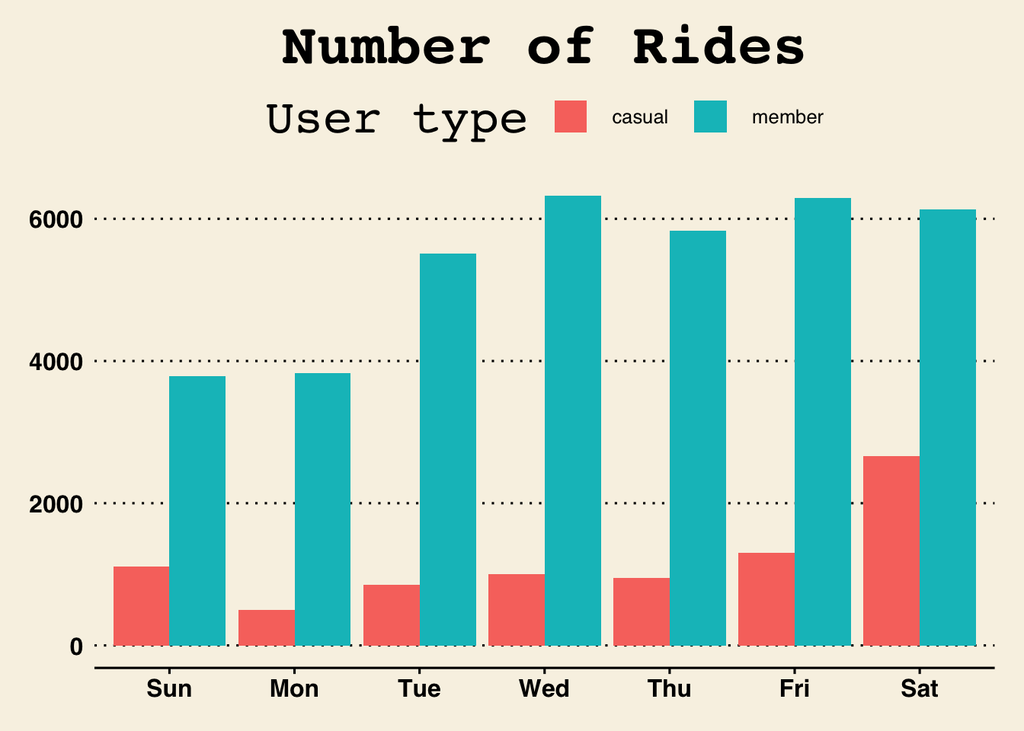

```r
# visualization of number of rides
feb21inrange %>%
  mutate(weekday = wday(started_at, label = TRUE)) %>%
  group_by(member_casual, weekday) %>%
  summarise(number_of_rides = n()
            ,average_duration = mean(seconds())) %>%
  arrange(member_casual, weekday)  %>%
  ggplot(aes(x = weekday, y = number_of_rides, fill = member_casual)) +
  geom_col(position = "dodge") + theme_wsj() + ggtitle("Number of Rides") +
  labs(fill = "User type") + theme(plot.title = element_text(hjust = 0.5))
```

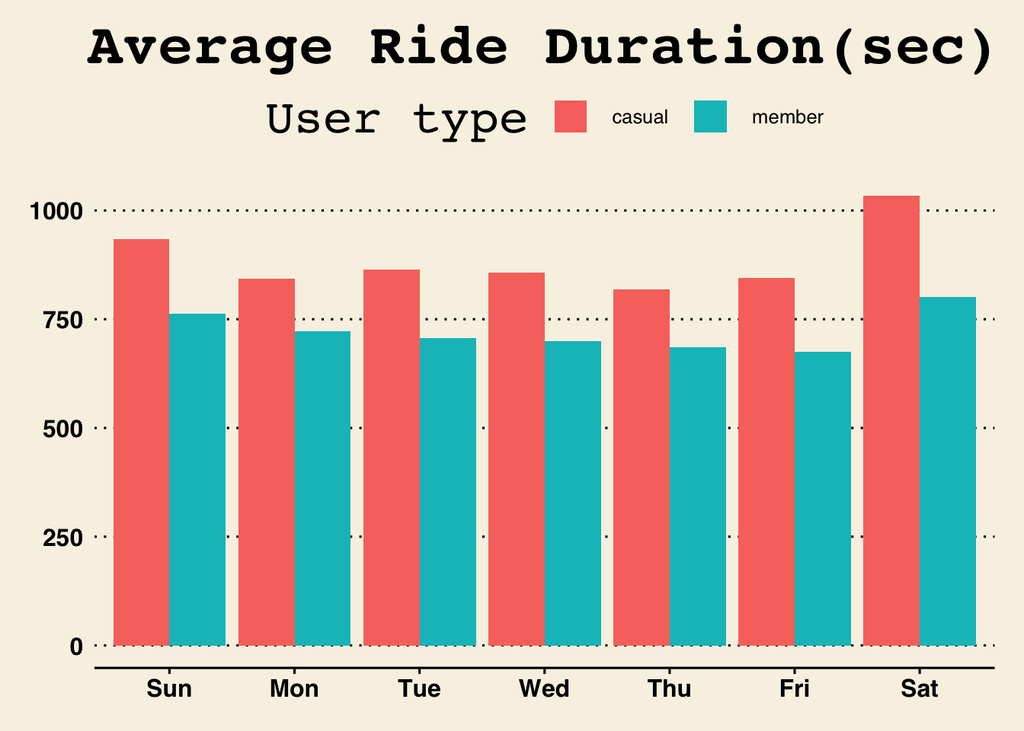

```r
# visualization for average duration
feb21inrange %>%
  mutate(weekday = wday(started_at, label = TRUE)) %>%
  group_by(member_casual, weekday) %>%
  summarise(number_of_rides = n()
            ,average_duration = mean(seconds)) %>%
  arrange(member_casual, weekday)  %>%
  ggplot(aes(x = weekday, y = average_duration, fill = member_casual)) +
  geom_col(position = "dodge") + theme_wsj() +
  theme_wsj() + ggtitle("Average Ride Duration(sec)") +
  labs(fill = "User type") + theme(plot.title = element_text(hjust = 0.5))
```

Some Observations: We notice that total number of rides is dominated by members throughout the week. If we look at the numbers of casual riders though, there is a significant spike on Saturday. Marketers could utilize this fact and have more presence in target locations on Saturday Secondly we also notice that casual members ride the bike longer than members consistently over all 7 days of the week. Further analysis can be done whether this difference is statistically significant. If found to be so, cost adjustments could be made so that a membership is more attractive for longer (casual) bike riders.